# 1 引子

## Excel表格

Excel表格是微软出的Office办公套件，相信大家都不陌生，尤其是在座各位在税务局工作的朋友，平时做数据处理、统计分析、辅助决策都能用得上

[figure not shown]

## 函数公式

平时做财务报表，难免要用到一些加减乘除数学运算，如果全靠自己手动算，然后再输入，不可避免地会出现小错误， 所以我们希望报表能自动计算，于是就有了Excel公式，但Excel的公式不太好写，而且也只能处理较简单的逻辑

[figure not shown]

## VBA编程

较复杂的逻辑就得靠VBA编程来实现了，VBA全称叫Visual Basic for Applications，这是微软开发的用来扩展Windows应用程序功能的一种语言

[figure not shown]

但现阶段学VBA并不是一个明智的选择：

- **不容易学**，没有好用的开发环境，错误调试不方便
- **性能不行**，在数据量大的情况下运行很耗时
- **适用面窄**，只能服务于Windows系统

既然要学一门编程语言，为何不与时俱进，学一门最时髦最先进的语言呢？在当前的国际形势下，自主可控的国产操作系统是大势所趋，大概率是Linux的某个发行版，Windows终将被放弃！

## 高级程序语言

[figure not shown]

计算机行业经过几十年的高速发展，诞生了形形色色的高级程序语言，它们都是应各种不同的需求而诞生，比如

- C / C++：高效，系统编程，科学计算
- Java：跨平台特性好，网络编程
- JavaScript / PHP：交互性好，嵌入浏览器

## 为什么要学Python？

网上有很多人说：“人生苦短，我用Python！”，为啥？最直接的原因是**简单好用**，对非程序员友好

具体来说是：

- **简单轻量**：学起来快，稍有编程经验的人一周就能上手，不像C / C++那么heavy
- **功能强大**：Web开发、科学计算、网络爬虫、数据分析、量化交易，几乎无所不能
- **社区活跃**：大量的第三方库让你永远可以站在巨人的肩膀上，无需浪费时间重复造轮子
- **免费使用**：任何人、组织、机构都可以免费使用Python，不像Java那么商业化

Python的劣势：

- 运行慢？混合编程，底层计算用C / C++ / Fortran来实现
- 不适合大项目？知乎、豆瓣、Youtube、Instagram
- 版本多、依赖容易崩？Windows下可以用Anaconda管理，类Unix系统下可以用Pacman、Homebrew等包管理器

## 一个例子

C++：

```
#include <iostream>
int main() {
    std::cout << "你好，华科！"; return 0;
}
```

Pyhton：

```
print("你好，华科！")
```

同样是打印“你好，华科！”到屏幕，对比可以看出Python的简洁

动手试一下：

```python
print("你好，华科！")
```

```
你好，华科！
```

## 编译型语言 vs. 解释性语言

- 编译型语言：事先将高级程序语言翻译成机器语言（俗称编译），然后再运行，执行效率高
- 解释性语言：执行一句翻译一句，不需要先编译，交互性好，执行效率低

C / C++属于前者，Python属于后者，由于它有很好的交互性，所以我选择不用ppt，而是这样一个方便交互和展示的形式

# 2 环境搭建

## Windows / Mac

1. 在[Python官网](https://www.python.org/downloads/release/python-380/)分别下载 Windows x86-64 executable installer 和 macOS 64-bit installer 安装包，最新版本是Python3.8：

[figure not shown]

2. Windows下安装时注意勾选**将Python添加到环境变量**，否则在非系统路径下无法调用Python。

## Linux

Linux下比较简单，各个发行版的官方软件仓库里都有Python，直接在Shell中安装即可，有的发行版甚至装机自带

- Arch系：`sudo pacman -S python`
- Debian系：`sudo apt-get install python3.*`
- RedHat系：`sudo yum install python3*`

讲者的电脑用的是Arch Linux，所以安装过程如下（官方软件仓库里还没更新到3.8，版本还是3.7.4）：

[figure not shown]

安装成功后，Windows下进入命令行，Mac / Linux进终端，输入`python`回车出现如下界面就代表环境搭建成功了：

[figure not shown]

## 开发环境

直接在命令行里写代码显然是痛苦且低效的，推荐两个开发环境：

1. vscode + python + tab nine + code runner + bracket pair colorizer，vscode是现在非常流行的文本编辑器，拥有丰富的第三方插件，装上后面四个插件就可以高效地写代码了，tab nine负责智能补全，bracket pair colorizer括号配对着色，code runner右键直接运行

[figure not shown]

1. jupyter lab / notebook，现在用的就是这个，交互性好，可以同时运行Python代码和显示Markdown文本，非常适合用来展示

# 3 基础知识

除了在命令行交互环境中运行外，还可以将若干条python语句写在一个*.py文件中，然后用命令`python* .py`运行

如下图所示，在untitled.py文件中写入了`print("你好，华科！")`和`print(2+3)`两条打印语句

[figure not shown]

## 保留字

保留字都有特殊含义，不能用来命名别的变量，前面见过的用来打印输出的`print`就是一个保留字

| and | exec | not | assert | finally | or | break | for | pass | class |
| --- | --- | --- | --- | --- | --- | --- | --- | --- | --- |
| from | print | continue | global | raise | def | if | return | del | import |
| try | elif | in | while | else | is | with | except | lambda | yield |

## 行和缩进

与C / C++不同，Python的代码块不使用大括号`{}`来判断，而是用缩进来表示

动手试一下：

```python
if 3 > 2:
    print(3)
else:
    print(2)
    print(1)  # 与else相关
```

```
3
```

```python
if 3 > 2:
    print(3)
else:
    print(2)
print(1)  # 与else无关
```

```
3
1
```

## 引号

Python使用单引号`'`、双引号`"`、三引号`'''`或`"""`来表示字符串，引号的开始与结束必须相同

其中三引号可以由多行组成，常用于做注释，单行注释也可用`#`来表示

动手试一下：

```python
"""
这个程序用来测试缩进
这个程序用来测试缩进
"""
# 这个程序用来测试缩进
if 3 > 2:
    print('你好')
else:
    print("华科")
```

```
你好
```

# 4 基础语法

## 变量

- 数值型变量

动手试一下：

```python
a = 2
b = 3
print(a+b)
```

```
5
```

- 字符串变量

动手试一下：

```python
a = "你好"
b = "华科"
print(a + "，" + b + "！")
```

```
你好，华科！
```

```python
str = "你好，华科！"         # 一共6个字符 0:你 1:好 2:，3:华 4:科 5:！
print(str)                 # 完整字符串
print(len(str))            # 字符串长度
print(str[0])              # 字符串中的第一个字符
print(str[2:5])            # 字符串中第3~5个
print(str[2:])             # 从第3个字符开始到结束
print(str * 2)             # 输出字符串两次
print(str + "你好，武汉！")  # 连接字符串 上一个例子已经用过
```

```
你好，华科！
6
你
，华科
，华科！
你好，华科！你好，华科！
你好，华科！你好，武汉！
```

## 列表

字符串是一种特殊的列表，**列表允许元素不同类型**

动手试一下：

```python
list1 = ["你好", 2 , "华科", 3]  # 列表用中括号[]
list2 = ["Hello", 'HUST']

print(list1)           # 完整列表
print(list1[0])        # 列表的第一个元素
print(list1[1:3])      # 第2~3个元素
print(list1[2:])       # 从第3个元素开始到结束
print(list1 * 2)       # 输出列表两次
print(list1 + list2)   # 连接列表
print([list1,[list2]]) # 列表的元素可以还是列表 即嵌套
```

```
['你好', 2, '华科', 3]
你好
[2, '华科']
['华科', 3]
['你好', 2, '华科', 3, '你好', 2, '华科', 3]
['你好', 2, '华科', 3, 'Hello', 'HUST']
[['你好', 2, '华科', 3], [['Hello', 'HUST']]]
```

排序，求和

动手试一下：

```python
list = [2, 4, 1, 3]
list.sort() # 默认升序
print(list)

list = [2, 4, 1, 3]
list.sort(reverse = True) # 降序
print(list)

print(sum(list))  # 求和
```

```
[1, 2, 3, 4]
[4, 3, 2, 1]
10
```

## 字典

列表是有序的对象集合，字典是无序的对象集合，由**索引**（key）和它对应的**值**（value）组成

字典当中的元素是通过**键**来存取的，而不是通过**下标**存取

动手试一下：

```python
dict = {}  # 字典用大括号{}
dict['Hello'] = "你好"
dict["HUST"] = "华科"

print(dict['Hello'])    # 输出键为Hello的值
print(dict['HUST'])     # 输出键为HUST的值
print(dict.keys())      # 输出所有键
print(dict.values())    # 输出所有值
```

```
你好
华科
dict_keys(['Hello', 'HUST'])
dict_values(['你好', '华科'])
```

# 5 运算

## 算数运算

- 加法，减法，乘法，除法，乘方

动手试一下：

```python
1 + 2, 2 - 1, 2 * 3, 3 / 5, 2**3, 4**(1/2)
```

```
(3, 1, 6, 0.6, 8, 2.0)
```

- 取模，取整

动手试一下：

```python
a = 13%3; b = 13%5; c = 13//3; d = 13//5
print(a)
print(b)
print(c)
print(d)
```

```
1
3
4
2
```

- 对数

动手试一下：

```python
'''
引入Python自带的math模块
import也是Python保留字
'''
import math
math.log2(8), math.log10(100), math.log(math.exp(5))
```

```
(3.0, 2.0, 5.0)
```

**通过按tab健提示可以看到math模块里还有（反）三角函数**

[figure not shown]

- 正弦，余弦，正切

动手试一下：

```python
math.sin(math.pi/2), math.cos(math.pi/2), math.tan(math.pi/4)
```

```
(1.0, 6.123233995736766e-17, 0.9999999999999999)
```

- 向上取整，向下取整

动手试一下：

```python
math.ceil(3.6), math.floor(3.6)
```

```
(4, 3)
```

## 比较运算

判断某条语句是否成立

```python
print(a,b,c,d)  # 上面取模取整的输出
if a < b:
    print("a小于b")
if a <= b:
    print("a小于等于b")
if a == 1:
    print("a等于1")
if a != b:
    print("a不等于b")
```

```
1 3 4 2
a小于b
a小于等于b
a等于1
a不等于b
```

大于`>`和大于等于`>=`同理，不赘述

## 逻辑运算

- 与：全部都成立才算成立

动手试一下：

```python
if a < b and c > d:
    print("a小于b 和 c大于d 同时成立")
if a < b and c <= d:
    print("a小于b 和 c小于等于d 同时成立")
```

```
a小于b 和 c大于d 同时成立
```

- 或：有一个成立就成立

动手试一下：

```python
if a < b or c <= d:
    print("a小于b 和 c小于等于d 同时成立")
if a > b or c <= d:
    print("a大于b 和 c小于等于d 同时成立")
```

```
a小于b 和 c小于等于d 同时成立
```

- 非：取反

动手试一下：

```python
if not a < b:
    print("a小于b 不成立")
if not a >= b:
    print("a大于等于b 不成立")
```

```
a大于等于b 不成立
```

## 成员运算

判断列表是否包含某个元素

动手试一下：

```python
list1 = ["你好", 2 , "华科", 3]  # 列表用中括号[]
list2 = ["Hello", 'HUST']
if 2 in list1:
    print("2在列表1中")
else:
    print("2不在列表1中")

if 'H' not in list2[0]:
    print("H不在列表2中")
else:
    print("H在列表2中")
```

```
2在列表1中
H在列表2中
```

# 6 循环

- while循环

动手试一下：

```python
i = 0
while i < 5:
    print(i)
    i += 1     # i = i + 1
```

```
0
1
2
3
4
```

- for循环

动手试一下：

```python
for i in range(5):  # range可以很方便的构建列表 range(5) = [0, 1, 2, 3, 4]
    print(i**2)
```

```
0
1
4
9
16
```

```python
for i in range(0,5,2):  # range(0,5,2) = [0, 2, 4] 0是开始数 5是结束数（不包括） 相邻两数差为2
    print(i)
```

```
0
2
4
```

- `break`跳出循环，循环的剩余部分不再执行

动手试一下：

```python
for i in range(5):  # range(5) = [0, 1, 2, 3, 4]
    print(i)
    if i == 3:
        break
```

```
0
1
2
3
```

- `continue`忽略本轮循环剩余部分

动手试一下：

```python
for i in range(5):  # range(5) = [0, 1, 2, 3, 4]
    if i == 3:
        continue
    print(i)
```

```
0
1
2
4
```

# 7. 字符串

前面已经见过字符串的简单操作

```python
str = "你好，华科！"         # 一共6个字符 0:你 1:好 2:，3:华 4:科 5:！
print(str)                 # 完整字符串
print(len(str))            # 字符串长度
print(str[0])              # 字符串中的第一个字符
print(str[2:5])            # 字符串中第3~5个
print(str[2:])             # 从第3个字符开始到结束
print(str * 2)             # 输出字符串两次
print(str + "你好，武汉！")  # 连接字符串 上一个例子已经用过
```

```
你好，华科！
6
你
，华科
，华科！
你好，华科！你好，华科！
你好，华科！你好，武汉！
```

## 替换

动手试一下：

```python
str = "你好，华科！你好，武汉！"
str2 = str.replace("你好", "Hello")
print(str2)
str3 = str.replace("你好", "Hello", 1)  # 第三个参数指定替换次数
print(str3)
```

```
Hello，华科！Hello，武汉！
Hello，华科！你好，武汉！
```

同样通过按tab健提示可以看看字符串还有哪些函数

[figure not shown]

## 查找

动手试一下：

```python
str = "你好，华科！你好，武汉！你好，湖北！你好，中国！"
print(str.find("华科"))      # 找到子串则返回子串首字符在原字符串中的下标
print(str.find("华科大"))    # 找不到返回-1
```

```
3
-1
```

## 分割

动手试一下：

```python
str = "你好，华科！你好，武汉！你好，湖北！你好，中国！"
str2 = str.split('！')  # 以！对字符串str进行分割
for a in str2:
    print(a)
```

```
你好，华科
你好，武汉
你好，湖北
你好，中国
```

## 合并

动手试一下：

```python
str_list = ["你好，华科", "你好，武汉", "你好，湖北", "你好，中国", ""]
"！".join(str_list)  # 以！为分隔符，将str_list中的所有字符串合并起来 多用于将路径合并成完整路径
```

```
'你好，华科！你好，武汉！你好，湖北！你好，中国！'
```

## 正则表达式

正则表达式（Regular Expression）是**描述某种规则的表达式**，通常被用来**检索或替换那些符合某个模式的文本**，比上面的精确匹配更强大

下面是一个识别合法ip的例子，注意ip由4个0-255的数字组成，因此每个数字有三种可能：

- 非零个位数，因此是`[1-9]`
- 两位是，十位不能是0，因此是`[1-9][0-9]`
- 三位数，百位只能是1或2，因此是`[1-2][0-9][0-9]`

动手试一下：

```python
import re  # 导入python自带的re模块

str = '192.168.1.100'
m = re.match('([1-9]|[1-9][0-9]|[1-2][0-9][0-9])\.([1-9]|[1-9][0-9]|[1-2][0-9][0-9])\.([1-9]|[1-9][0-9]|[1-2][0-9][0-9])\.([1-9]|[1-9][0-9]|[1-2][0-9][0-9])$', str)
m.groups()
```

```
('192', '168', '1', '100')
```

`|`表示或，因为每个数字有三种合法的形式；`\.`表示点号本身，因为点号在正则表达式中表示任意字符，需要反斜杠转义

下面是一个从字符串列表中提取手机号和身份信息的例子，由于有的手机号有区号，有的没区号，身份信息有的用身份证，有的用护照，所以只能求助于正则表达式

动手试一下：

```python
list = ["小平的手机号1389876543，身份证号320811190012344321。",
        "小强的手机号+861591234567，身份证号40140511200056788765。",
        "Trump的手机号+1-222-333-4444，护照号E12345789。"]
for str in list:
    print(str)
```

```
小平的手机号1389876543，身份证号320811190012344321。
小强的手机号+861591234567，身份证号40140511200056788765。
Trump的手机号+1-222-333-4444，护照号E12345789。
```

```python
pattern = re.compile(r'([1+][0-9-]*)，')  # 手机号匹配模式
for str in list:
    r = pattern.findall(str)  # findall查找所有的匹配
    print(r)
print("-----------------------------------------")
pattern = re.compile(r'号([0-9]{18}|[A-Z][0-9]{8})')   # 身份信息匹配模式 {}中的数字表示前面[]中的模式出现的次数
for str in list:
    r = pattern.findall(str)  # findall查找所有的匹配
    print(r)
```

```
['1389876543']
['+861591234567']
['+1-222-333-4444']
-----------------------------------------
['320811190012344321']
['401405112000567887']
['E12345789']
```

- 手机号匹配模式是`([1+][0-9-]*)，`，表示以`1`或`+`起始，以`，`结束，由数字`0-9`和`-`构成的字符串序列
- 身份信息匹配模式是`([0-9]{18})`，表示18位身份证数字；或者`([A-Z][0-9]{8})`，表示1位字母加8位数字的9位护照

下面是一个删掉注释的例子

动手试一下：

```python
list = ["小平的手机号1389876543，身份证号320811190012344321。",
        "小强的手机号+861591234567，身份证号40140511200056788765。 # +86是中国区号",
        "Trump的手机号+1-222-333-4444，护照号E12345789。 # 外国友人没有身份证"]
for str in list:
    print(str)
print("-----------------------------------------")
pattern = re.compile(r'#.*$')    # .表示任意字符 #.*表示#打头任意长的字符串
for str in list:
    print(pattern.sub("", str))  # sub将所有匹配替换为空字符串 即删掉注释
```

```
小平的手机号1389876543，身份证号320811190012344321。
小强的手机号+861591234567，身份证号40140511200056788765。 # +86是中国区号
Trump的手机号+1-222-333-4444，护照号E12345789。 # 外国友人没有身份证
-----------------------------------------
小平的手机号1389876543，身份证号320811190012344321。
小强的手机号+861591234567，身份证号40140511200056788765。
Trump的手机号+1-222-333-4444，护照号E12345789。
```

`.`表示任意字符，`$`表示字符串结尾，因此`#.*$`表示`#`打头任意长的字符串

# 8. 文件操作

## 文本文件

- 读文件

动手试一下：

```python
with open("files/untitled.py", "r", encoding="utf-8") as read_file:  # r表示以只读的方式打开
    for line in read_file:  # 一行一行读
        print(line)
```

```
print("你好，华科！")

print(2+3)
```

- 写文件

动手试一下：

```python
with open("files/untitled.py", "w+", encoding="utf-8") as write_file:  # w表示以可写入的方式打开
    write_file.write("for i in range(5):\n")
    write_file.write("    print(i**2)\n")
```

[figure not shown]

不难发现原来的两条打印语句被覆盖了，只剩下新写入的两条语句了，如果想保留原有内容，要用**追加模式**打开文件

动手试一下：

```python
with open("files/untitled.py", "a+", encoding="utf-8") as write_file:  # a+ 追加模式 append
    write_file.write("print(\"你好，华科！\")\n")  # \"对双引号转义
    write_file.write("print(2+3)\n")
```

[figure not shown]

## Excel表格

Python可以处理Excel表格，这需要依赖第三方库 python-xlrd 和 python-xlwt，分别用来读Excel和写Excel

- Windows下可以通过Anaconda安装，**不推荐用pip安装**
- 类Unix系统下用系统自带的包管理器安装即可，例如Arch系用`sudo pacman -S python-xlrd python-xlwt`

[figure not shown]

动手试一下：

```python
import xlrd
data = xlrd.open_workbook('files/exam.xlsx')
table = data.sheet_by_name('Sheet1')   # 获取sheet 1
print(table.nrows, table.ncols)        # 行数 列数

for i in range(table.nrows):
    print(table.row_values(i))         # 打印第i行的值
print("-----------------------------------------")
for j in range(table.ncols):
    print(table.col_values(j))         # 打印第j列的值
print("-----------------------------------------")
table.cell(2,3).value                  # 打印第3行第4列的单元格值
```

```
6 5
[1.0, 2.0, 3.0, 4.0, 5.0]
[6.0, 7.0, 8.0, 9.0, 10.0]
[11.0, 12.0, 13.0, 14.0, 15.0]
[16.0, 17.0, 18.0, 19.0, 20.0]
[21.0, 22.0, 23.0, 24.0, 25.0]
[26.0, 27.0, 28.0, 29.0, 30.0]
-----------------------------------------
[1.0, 6.0, 11.0, 16.0, 21.0, 26.0]
[2.0, 7.0, 12.0, 17.0, 22.0, 27.0]
[3.0, 8.0, 13.0, 18.0, 23.0, 28.0]
[4.0, 9.0, 14.0, 19.0, 24.0, 29.0]
[5.0, 10.0, 15.0, 20.0, 25.0, 30.0]
-----------------------------------------
```

```
14.0
```

```python
import xlwt
workbook = xlwt.Workbook()
worksheet = workbook.add_sheet('My Sheet')
font = xlwt.Font() # Create the Font
font.name = '方正苏新诗柳楷简体-yolan'
font.bold = True
font.underline = True
font.italic = True
style = xlwt.XFStyle()                 # 创建字体样式
style.font = font
worksheet.write(0, 0, '你好，')
worksheet.write(0, 1, '华科！', style)  # 应用字体样式到该单元格
workbook.save('files/exam.xls')
```

[figure not shown]

# 9. 常用第三方库

## NumPy

NumPy（Numerical Python）支持高维数组和矩阵运算，提供大量的数学函数库，安装方法与前面的python-xlrd类似

和，均值，标准差

动手试一下：

```python
import numpy as np

a = np.array([2, 4, 1, 3])  # 将列表转换成数组
sum(a), np.mean(a), np.std(a)
```

```
(10, 2.5, 1.118033988749895)
```

```python
b = np.argsort(a)
b
```

```
array([2, 0, 3, 1])
```

二维数组

动手试一下：

```python
a = np.array([[2, 4, 6], [5, 3, 1]])  # 将列表转换成数组
a
```

```
array([[2, 4, 6],
       [5, 3, 1]])
```

二维数组全部元素求和，竖向求和，横向求和

动手试一下：

```python
np.sum(a), np.sum(a, axis=0), np.sum(a, axis=1)
```

```
(21, array([7, 7, 7]), array([12,  9]))
```

改变形状

动手试一下：

```python
b = np.reshape(a, (3, 2))  # 转成3行2列
b
```

```
array([[2, 4],
       [6, 5],
       [3, 1]])
```

有了强大的二维数组处理工具，可以将Excel表格中的数据全部导入Python中，用NumPy进行复杂的逻辑处理后，再写回到Excel中

## Matplotlib

最常用的绘图库

动手试一下：

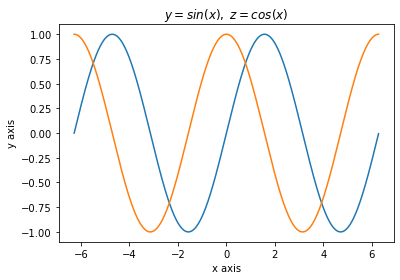

```python
# 画曲线走势
%matplotlib inline
import math
import numpy as np
from matplotlib import pyplot as plt

x = np.arange(-2*math.pi, 2*math.pi, 0.01)
y = []
z = []
for i in range(len(x)):
    y.append(math.sin(x[i]))
    z.append(math.cos(x[i]))
    i += 1

plt.title("$y = sin(x),~z = cos(x)$")
plt.xlabel("x axis")
plt.ylabel("y axis")
plt.plot(x,y)
plt.plot(x,z)
plt.show()
```

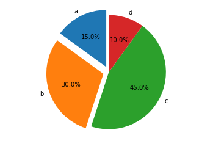

```python
# 画饼状图
%matplotlib inline
import matplotlib.pyplot as plt

labels = 'a', 'b', 'c', 'd'
sizes = [15, 30, 45, 10]    # 百分比
explode = (0.1, 0.1, 0, 0)  # a, b 饼块突出显示

plt.pie(sizes, explode=explode, labels=labels, autopct='%1.1f%%', shadow=False, startangle=90)
plt.axis('equal')

plt.show()
```

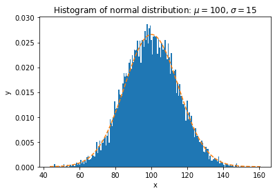

```python
# 画条形图
%matplotlib inline
import matplotlib
import numpy as np
import matplotlib.pyplot as plt

np.random.seed(19680801)

mu = 100    # 正态分布均值
sigma = 15  # 正态分布标准差
x = mu + sigma * np.random.randn(10000)

num_bins = 200

n, bins, patches = plt.hist(x, num_bins, density=1)

y = ((1 / (np.sqrt(2 * np.pi) * sigma)) * np.exp(-0.5 * (1 / sigma * (bins - mu))**2))  # 正态分布函数
plt.plot(bins, y, '--')
plt.xlabel('x')
plt.ylabel('y')
plt.title(r'Histogram of normal distribution: $\mu=100$, $\sigma=15$')
plt.show()
```

## SciKit-Learn

最流行的机器学习库，几乎包含所有经典的机器学习算法

动手试一下：

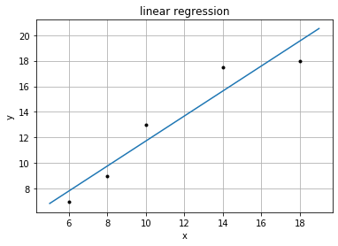

```python
# 线性回归：用线性函数拟合数据
%matplotlib inline
import sklearn
import numpy as np
import matplotlib.pyplot as plt
from sklearn.linear_model import LinearRegression

x = np.array([6, 8, 10, 14, 18]).reshape(-1, 1)  # 5个样本点构成的数据集
y = [7, 9, 13, 17.5, 18]

model = LinearRegression()  # 选择学习模型：线性回归
model.fit(x, y)             # 拟合数据

xx = np.arange(5, 20, 1).reshape(-1, 1)
yy = []
for i in range(len(xx)):
    yy.append(model.predict(np.array([xx[i]])))  # 线性回归模型
    i += 1

plt.figure()
plt.title("linear regression")
plt.xlabel("x")
plt.ylabel("y")
plt.plot(x, y, "k.")
plt.plot(xx, yy)
plt.grid(True)
plt.show()
```

# 10. 总结

在短短的几小时里想讲清楚Python的方方面面是不可能的，所以这个slides只选择性地介绍了一些我觉得会对大家有用的内容

有些不难理解的内容比如**函数**，它的作用只是提高代码复用率，这里就略过了；比较有难度的内容大多也是浅尝辄止没有深入，比如正则表达式，还有最后这几个经典的第三方库。如果把一门科普课上成劝退课，就有违初衷了

俗话说“师父领进门修行在个人”，今后还要靠大家自己深入钻研。一门语言初接触肯定会有些许不顺手，但此时千万不能知难而退，一旦退了就永远也学不会了。挺过前面短暂的阵痛期，后面就是康庄大道

祝在座的各位朋友今后都成为能熟用Python解决问题的业务能手！